# A4

Antonio Roldan Andrade

2026-01-11

# Actividad 4

## 1. Preprocesamiento

### 1.1 Nombres de las variables

```r
# Comenzamos por la carga del diccionario CSV
csv_location <- "Findata.csv"
dataSet <- read.csv(csv_location, sep = ",")

# Realizamos las modificaciones pertinentes de los nombres:
dataSet <- dataSet %>%
  rename_with(~
                str_remove(., "\\.+$") %>% # Elimina los puntos al final nombres de variables
                str_replace_all(., "\\.+", "_") %>% # Sustituye los puntos dentro por _
                str_replace_all("__+", "_") # Si hay dos puntos seguidos, reemplazadlos por un único guion bajo.

              )
# Comprobamos
names(dataSet)
```

```
##  [1] "X"                            "Age"
##  [3] "Gender"                       "Weight_kg"
##  [5] "Height_m"                     "Max_BPM"
##  [7] "Avg_BPM"                      "Resting_BPM"
##  [9] "Session_Duration_hours"       "Calories_Burned"
## [11] "Workout_Type"                 "Fat_Percentage"
## [13] "Water_Intake_liters"          "Workout_Frequency_days_week"
## [15] "Experience_Level"             "BMI"
## [17] "Daily_meals_frequency"        "Physical_exercise"
## [19] "Carbs"                        "Proteins"
## [21] "Fats"                         "Calories"
## [23] "meal_name"                    "meal_type"
## [25] "diet_type"                    "sugar_g"
## [27] "sodium_mg"                    "cholesterol_mg"
## [29] "serving_size_g"               "cooking_method"
## [31] "prep_time_min"                "cook_time_min"
## [33] "rating"                       "Name_of_Exercise"
## [35] "Sets"                         "Reps"
## [37] "Benefit"                      "Burns_Calories_per_30_min"
## [39] "Target_Muscle_Group"          "Equipment_Needed"
## [41] "Difficulty_Level"             "Body_Part"
## [43] "Type_of_Muscle"               "Workout"
## [45] "BMI_calc"                     "cal_from_macros"
## [47] "pct_carbs"                    "protein_per_kg"
## [49] "pct_HRR"                      "pct_maxHR"
## [51] "cal_balance"                  "lean_mass_kg"
## [53] "expected_burn"                "Burns_Calories_per_30_min_bc"
## [55] "Burns_Calories_Bin"
```

### 1.2 Variables Weight_kg y Height_m

```r
# Comprobamos tipos de variables (con glympse, glimpse(dataSet))
# Se puede percibir que la columna Weight..kg. es incorrecta (marcada como character)

# Weight
dataSet <- dataSet %>%
  mutate(
    # Aseguramos que sea texto para limpiar, quitamos espacios
    Weight_kg = str_to_lower(as.character(Weight_kg)),

    # Si contiene "b para aplicar la conversión
    Weight_kg = case_when(
      str_detect(Weight_kg, "lb") ~ as.numeric(str_extract(Weight_kg, "[0-9.]+")) / 2.20,
      TRUE ~ as.numeric(str_extract(Weight_kg, "[0-9.]+"))
    )
  )
# Comprobamos datos
head(dataSet$Weight_kg)
```

```
## [1]  65.27  56.41  58.98  93.78  52.42 105.05
```

```r
# Height
dataSet <- dataSet %>%
  mutate(
    Height_m = str_to_lower(as.character(Height_m)),

    # Si contiene feet (') o inches (")
    Height_m = case_when(
      str_detect(Height_m, "'|\"|ft|in") ~ {
        # Extraemos todos los números encontrados
        numeros <- str_extract_all(Height_m, "[0-9.]+")
        # El primero son pies, el segundo pulgadas
        pies <- as.numeric(sapply(numeros, function(x) x[1]))
        pulgadas <- as.numeric(sapply(numeros, function(x) ifelse(length(x) > 1, x[2], 0)))
        # Convertimos: (pies * 12 + pulgadas) / 39.37
        (pies * 12 + pulgadas) / 39.37
      },
      # Si es numérico o solo necesita conversión de pulgadas a metros
      TRUE ~ as.numeric(str_extract(Height_m, "[0-9.]+"))
    )
  )

# Comprobamos datos
head(dataSet$Height_m)
```

```
## [1] 1.62 1.55 1.67 1.70 1.88 1.84
```

### Valores Ausentes y Atípicos

```r
# Weight

# Valores Ausentes
na_weight <- sum(is.na(dataSet$Weight_kg))

# Valores Atípicos
out_weight <- length(boxplot.stats(dataSet$Weight_kg)$out)

cat("Peso - Ausentes:", na_weight, "| Atípicos:", out_weight)
```

```
## Peso - Ausentes: 0 | Atípicos: 152
```

```r
# Height
na_height <- sum(is.na(dataSet$Height_m))

# Valores Atípicos
out_height <- length(boxplot.stats(dataSet$Height_m)$out)

cat("Altura - Ausentes:", na_height, "| Atípicos:", out_height)
```

```
## Altura - Ausentes: 0 | Atípicos: 0
```

## 2. Estadística inferencial

### 2.1.1. Hipótesis nula y Alternativa

Dada la pregunta: ¿Podemos aceptar que los hombres queman en promedio más calorías en los entrenamientos que las mujeres?

Podemos plantear lo siguiente:  
$H_0: \mu_{hombres} = \mu_{mujeres}$ (La media de calorías quemadas es igual en ambos grupos).  
$H_1: \mu_{hombres} > \mu_{mujeres}$ (La media de calorías en hombres es mayor que en mujeres).

### 2.1.2. Justificación del test a aplicar

Dado que se va a realizar un test estadistico entre medias de muestras independientes, además desconocemos las covarianza poblacional, por tanto usaremos la covarianza muestral y un t-test.

### 2.1.3 Cálculos

```r
# Calculo manual

# Separamos los grupos
hombres <- dataSet$Calories[dataSet$Gender == "Male"]
mujeres <- dataSet$Calories[dataSet$Gender == "Female"]

# Estadísticos
n1 <- length(hombres); n2 <- length(mujeres)
m1 <- mean(hombres);   m2 <- mean(mujeres)
s1 <- sd(hombres);     s2 <- sd(mujeres)

# Calculo del estadístico de contraste

se_diff <- sqrt((s1^2 / n1) + (s2^2 / n2))

# Estadístico t observado
t_obs <- (m1 - m2) / se_diff

# Aplicamos test de welch

df_welch <- ((s1^2/n1 + s2^2/n2)^2) / ((s1^2/n1)^2/(n1-1) + (s2^2/n2)^2/(n2-1))

# Valor Crítico (cola a la derecha)
t_critico <- qt(0.975, df = df_welch)

# P-valor

p_valor <- pt(t_obs, df = df_welch, lower.tail = FALSE)

# Resultados
cat("T-Critico manual:", t_critico,"\n","T-observado manual:", t_obs, "\n","P-valor manual:    ", p_valor, "\n")
```

```
## T-Critico manual: 1.960083
##  T-observado manual: 0.5141114
##  P-valor manual:     0.3035899
```

```r
# Calculo automatico
resultado_auto <- t.test(Calories ~ Gender, data = dataSet,
                         alternative = "greater",
                         conf.level = 0.975)
print(resultado_auto)
```

```
##
##  Welch Two Sample t-test
##
## data:  Calories by Gender
## t = -0.51411, df = 19998, p-value = 0.6964
## alternative hypothesis: true difference in means between group Female and group Male is greater than 0
## 97.5 percent confidence interval:
##  -18.96137       Inf
## sample estimates:
## mean in group Female   mean in group Male
##             2022.454             2026.394
```

### 2.1.4. Interpretación del test

Por tanto podemos concluir que si nos centramos en el T-observado ($0.514$) podemos ver como no supera al t-critico ($(1.96)$), en consecuencia no podemos rechazar la hipótesis nula (H0).

En cuanto al p-valor, tenemos que el valor observado es $0.304$ por lo que supera al nivel de significación haciendo que no podamos rechazar la hipótesis nula.

En consecuencia no podemos rechazar que la media de calorias quemadas por ambos grupos durante el transcurso de un ejercicio es aproximadamente igual en promedio, con un $97.5 %$ de confianza.

## 3. Modelo de regresión

### 3.1. Regresión lineal múltiple

```r
# Modelo de regresión lineal múltiple
modelo_calorias <- lm(Calories_Burned ~ Session_Duration_hours + Experience_Level +
                      Workout_Frequency_days_week + Height_m + Weight_kg +
                      Gender + Workout_Type,
                      data = dataSet)

summary(modelo_calorias)
```

```
##
## Call:
## lm(formula = Calories_Burned ~ Session_Duration_hours + Experience_Level +
##     Workout_Frequency_days_week + Height_m + Weight_kg + Gender +
##     Workout_Type, data = dataSet)
##
## Residuals:
##     Min      1Q  Median      3Q     Max
## -272.46  -49.96   -9.88   43.31  372.91
##
## Coefficients:
##                               Estimate Std. Error  t value Pr(>|t|)
## (Intercept)                 -365.97518    9.80638  -37.320   <2e-16 ***
## Session_Duration_hours      1052.84626    2.79080  377.256   <2e-16 ***
## Experience_Level              59.07094    1.46821   40.233   <2e-16 ***
## Workout_Frequency_days_week   37.05314    1.10226   33.616   <2e-16 ***
## Height_m                      14.47045    5.70921    2.535   0.0113 *
## Weight_kg                      0.03321    0.03427    0.969   0.3325
## GenderMale                     0.67295    1.35676    0.496   0.6199
## Workout_TypeHIIT             451.90977    1.92862  234.318   <2e-16 ***
## Workout_TypeStrength         151.98634    1.91970   79.172   <2e-16 ***
## Workout_TypeYoga            -297.30110    1.92313 -154.592   <2e-16 ***
## ---
## Signif. codes:  0 '***' 0.001 '**' 0.01 '*' 0.05 '.' 0.1 ' ' 1
##
## Residual standard error: 95.92 on 19990 degrees of freedom
## Multiple R-squared:  0.9635, Adjusted R-squared:  0.9635
## F-statistic: 5.87e+04 on 9 and 19990 DF,  p-value: < 2.2e-16
```

Una vez tenemos los resultados de aplicar la regresión lineal podemos observar como las variables que tienen menor significancia son:

1. El peso de la persona que esta realizando el entrenamiento.
2. El género de la persona.

Por lo que podemos intuir que una vez que conocemos la duración y el tipo de ejercicio, el peso y el género no añaden mucha información extra para predecir las calorías en este dataset.

Si nos centramos en la calidad del ajuste, podemos observar que el modelo tiene una gran robustez para realizar predicciones ya que:

1. R Cuadrado es de $0.9635$, por lo que las variables seleccionadas explican el $96%$ de la variabilidad de los datos.
2. Errores Estándar relativamente bajos comparados con los coeficientes (Estimates), lo que indica precisión en las estimaciones.

Por último tenemos la aportación del nivel de experiencia de la persona:

1. Por cada incremento en una unidad del nivel de experiencia, las calorías quemadas aumentan en promedio $59.07$ unidades, manteniendo constantes todas las demás variables (duración, tipo de ejercicio, etc.).
2. Esto sugiere que un usuario más experimentado es más eficiente o entrena con una intensidad interna mayor que un principiante, logrando quemar más calorías en el mismo tiempo y con la misma frecuencia de entrenamiento.

### 3.2. Multicolinealidad

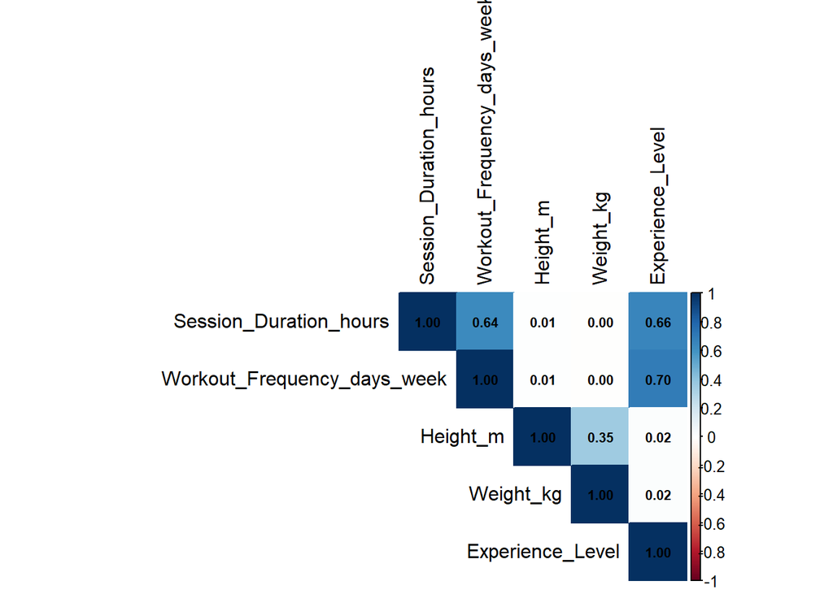

```r
# Matriz de correlacion
vars_cuant <- dataSet %>%
  select(Session_Duration_hours, Workout_Frequency_days_week, Height_m, Weight_kg, Experience_Level)

# Calculamos la matriz
matriz_cor <- cor(vars_cuant, use = "complete.obs")

# Visualización gráfica
corrplot(matriz_cor, method = "color", addCoef.col = "black",
         type = "upper", tl.col = "black", number.cex = 0.7)
```

Como podemos apreciar en la matriz podemos apreciar cierto nivel de correlación positiva:

1. **Experiencia de entrenamiento - Duración de la actvidad**
2. **Experiencia de entrenamiento - Días de entrenamiento por semana**
3. **Días de entrenamiento por semana - Duración de la actvidad**

Aunque tenemos cierto nivel de correlación podemos apreciar que no se trata en ningún caso de unas correlaciones altas.

```r
# Matriz VIF
vif_values <- vif(modelo_calorias)

print(vif_values)
```

```
##                                 GVIF Df GVIF^(1/(2*Df))
## Session_Duration_hours      1.972570  1        1.404482
## Experience_Level            2.282941  1        1.510941
## Workout_Frequency_days_week 2.192816  1        1.480816
## Height_m                    1.143372  1        1.069286
## Weight_kg                   1.144245  1        1.069694
## Gender                      1.000395  1        1.000197
## Workout_Type                1.001246  3        1.000208
```

## 3.3. Análisis visual de los residuos

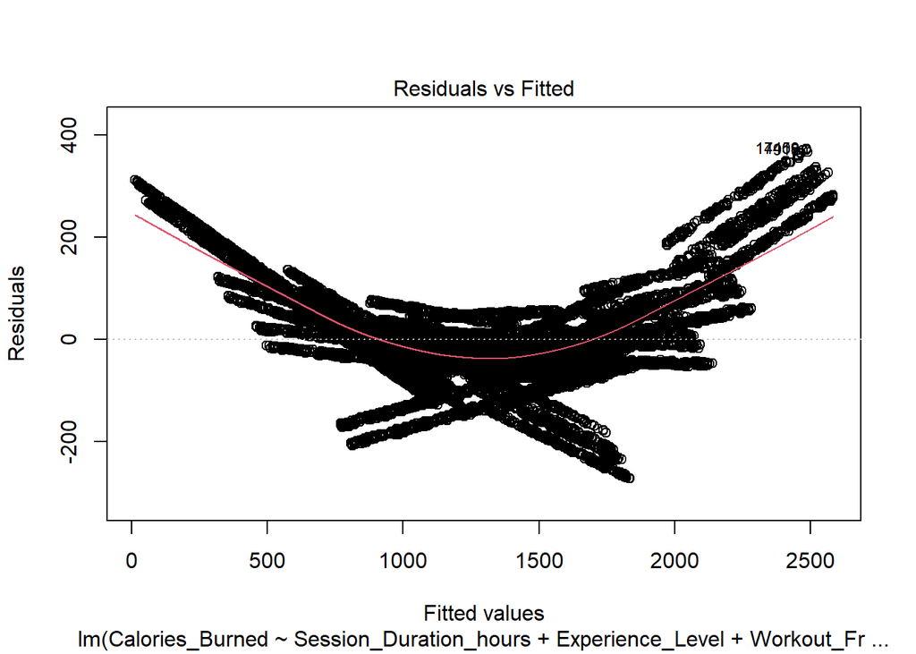

```r
plot(modelo_calorias, which =1 )
```

Si nos centramos en el primer gráfico (Residual VS Fitted) podemos apreciar como los datos se distribuyen en forma de curva, por tanto podemos afirmar que existe un problema de no linealidad. Esto indica que la relación entre las calorías y las variables explicativas (como la duración o el peso) no es puramente lineal, o que faltan términos cuadráticos o interacciones en el modelo.

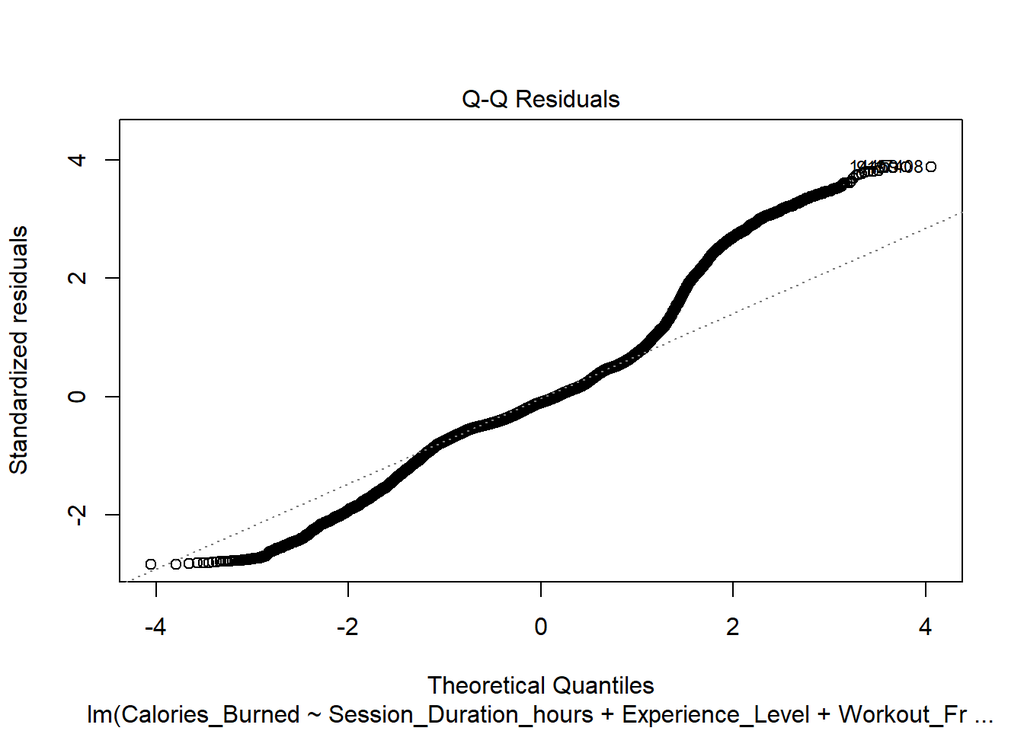

```r
plot(modelo_calorias, which =2 )
```

### 3.4. Regresión logística

```r
# 1. Crear la variable binaria: 1 si es principiante, 0 si no lo es
dataSet <- dataSet %>%
  mutate(Is_Beginner = ifelse(Experience_Level == 1, 1, 0))

# 2. Ajustar el modelo
modelo_logistico <- glm(Is_Beginner ~ Calories + Session_Duration_hours +
                        Workout_Frequency_days_week + Height_m + Weight_kg +
                        Gender + Workout_Type,
                        data = dataSet,
                        family = binomial)

summary(modelo_logistico)
```

```
##
## Call:
## glm(formula = Is_Beginner ~ Calories + Session_Duration_hours +
##     Workout_Frequency_days_week + Height_m + Weight_kg + Gender +
##     Workout_Type, family = binomial, data = dataSet)
##
## Coefficients:
##                               Estimate Std. Error z value Pr(>|z|)
## (Intercept)                 10.9294260  0.3186029  34.304   <2e-16 ***
## Calories                    -0.0002661  0.0001947  -1.367    0.172
## Session_Duration_hours      -3.2076236  0.0945883 -33.911   <2e-16 ***
## Workout_Frequency_days_week -1.8060422  0.0340062 -53.109   <2e-16 ***
## Height_m                    -0.2157027  0.1673842  -1.289    0.198
## Weight_kg                    0.0031231  0.0049700   0.628    0.530
## GenderMale                   0.0077481  0.0397465   0.195    0.845
## Workout_TypeHIIT            -0.0867855  0.0563172  -1.541    0.123
## Workout_TypeStrength        -0.0311174  0.0562154  -0.554    0.580
## Workout_TypeYoga             0.0586174  0.0565149   1.037    0.300
## ---
## Signif. codes:  0 '***' 0.001 '**' 0.01 '*' 0.05 '.' 0.1 ' ' 1
##
## (Dispersion parameter for binomial family taken to be 1)
##
##     Null deviance: 27579  on 19999  degrees of freedom
## Residual deviance: 15786  on 19990  degrees of freedom
## AIC: 15806
##
## Number of Fisher Scoring iterations: 6
```

Al observar la columna Pr(>|z|), vemos que solo hay dos variables que tienen un impacto estadísticamente significativo en la probabilidad de ser principiante:

- **Session_Duration_hours** (p-valor < 2e-16): Es altamente significativa. Su coeficiente es negativo (-3.20), lo que indica que a medida que aumenta la duración de la sesión, la probabilidad de ser una persona sin experiencia disminuye drásticamente.
- **Workout_Frequency_days_week** (p-valor < 2e-16): También es altamente significativa. Su coeficiente es negativo (-1.80), sugiriendo que cuantos más días a la semana entrena una persona, menor es la probabilidad de que sea clasificada como principiante.

En cuanto a la calidad del modelo podemos decir que el modelo ha reducido la devianza en casi un 43% ($1 - 15786/27579$). Siendo una reducción muy considerable, lo cual indica que el modelo tiene una buena capacidad discriminatoria. Las variables elegidas (especialmente frecuencia y duración) explican muy bien la pertenencia al grupo de principiantes.

### 3.5. Matriz de confusión

```r
# 1. Obtener las probabilidades predichas
probabilidades <- predict(modelo_logistico, type = "response")

# 2. Convertir probabilidades en 1 si prob >= 0.5, 0 si no
predicciones <- factor(ifelse(probabilidades >= 0.5, 1, 0), levels = c("0", "1"))
reales <- factor(dataSet$Is_Beginner, levels = c("0", "1"))

# 3. Generar la matriz
matriz_resultados <- confusionMatrix(predicciones, reales, positive = "1")
print(matriz_resultados)
```

```
## Confusion Matrix and Statistics
##
##           Reference
## Prediction    0    1
##          0 6801 1676
##          1 2343 9180
##
##                Accuracy : 0.799
##                  95% CI : (0.7934, 0.8046)
##     No Information Rate : 0.5428
##     P-Value [Acc > NIR] : < 2.2e-16
##
##                   Kappa : 0.5928
##
##  Mcnemar's Test P-Value : < 2.2e-16
##
##             Sensitivity : 0.8456
##             Specificity : 0.7438
##          Pos Pred Value : 0.7967
##          Neg Pred Value : 0.8023
##              Prevalence : 0.5428
##          Detection Rate : 0.4590
##    Detection Prevalence : 0.5762
##       Balanced Accuracy : 0.7947
##
##        'Positive' Class : 1
##
```

La matriz muestra los aciertos y errores del modelo de la siguiente manera:

1. **Verdaderos Positivos (VP)**: 9,180. El modelo identificó correctamente a 9,180 personas que realmente no tienen experiencia (Clase 1).
2. **Verdaderos Negativos (VN):** 6,801. El modelo identificó correctamente a 6,801 personas que sí tienen experiencia (Clase 0).
3. **Falsos Positivos (FP)**: 2,343. El modelo clasificó como principiantes a 2,343 personas que en realidad tienen experiencia (Error tipo I).
4. **Falsos Negativos (FN)**: 1,676. El modelo clasificó como expertos a 1,676 personas que en realidad son principiantes (Error tipo II).

En cuanto a sensibilidad y especificidad:

- **Sensibilidad (0.8456)**: El modelo identifica correctamente al 84.56% de todas las personas sin experiencia. Es un valor alto, lo que sugiere que el modelo es muy eficaz.
- **Especificidad (0.7438)**: El modelo identifica correctamente al 74.38% de las personas con experiencia. Es un valor sólido, aunque ligeramente inferior a la sensibilidad.

## 4. Análisis de la varianza (ANOVA) de un factor

### 4.1. Visualización

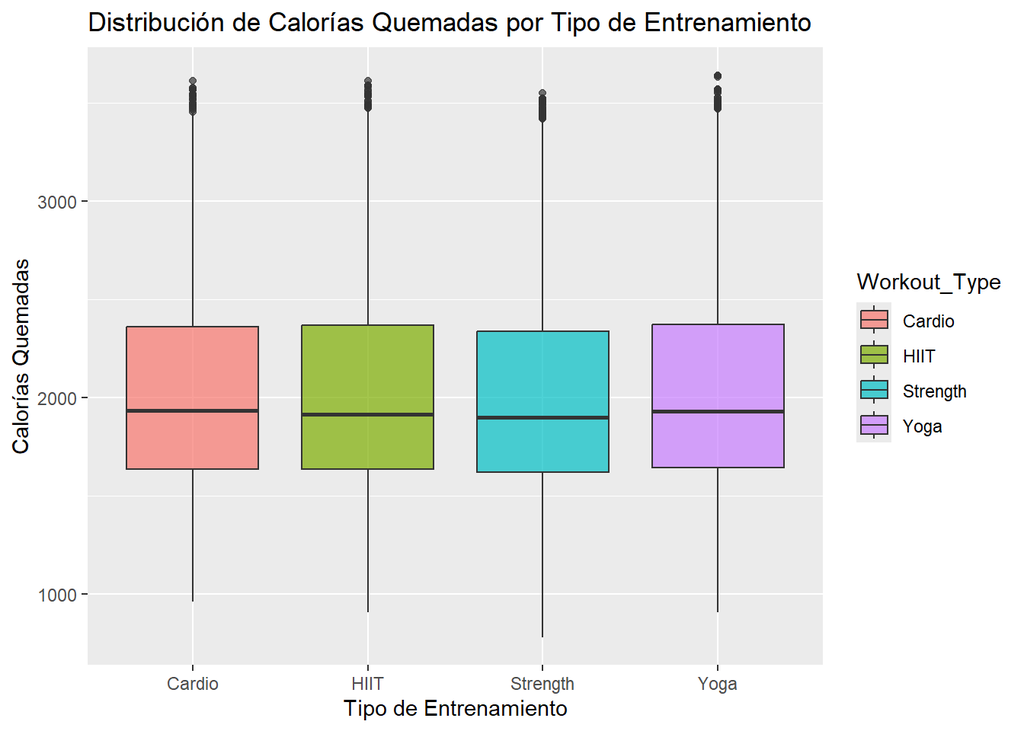

```r
ggplot(dataSet, aes(x = Workout_Type, y = Calories, fill = Workout_Type)) +
  geom_boxplot(alpha = 0.7) +
  labs(title = "Distribución de Calorías Quemadas por Tipo de Entrenamiento",
       x = "Tipo de Entrenamiento",
       y = "Calorías Quemadas")
```

### 4.2. Hipótesis nula y alternativa

La hipotesis nula establece que no existen difrencias en las medias de las calorías quemadas entre los diferentes entrenamientos.

La hipotesis alternativa plantea que existe al menos una de las medias de las calorias quemadas que si es diferente de las demas, quedando de la siguiente manera:

$$H_0: \mu_{\text{Cardio}} =
\mu_{\text{HIIT}} = \mu_{\text{Strength}} = \mu_{\text{Yoga}}$$
$$H_1: \exists \, i, j \text{ tales que }
\mu_i \neq \mu_j$$

### 4.3 Modelo

```r
# Realizamos el ANOVA
modelo_anova <- aov(Calories ~ Workout_Type, data = dataSet)

# Mostramos la tabla de resultados
summary(modelo_anova)
```

```
##                 Df    Sum Sq Mean Sq F value Pr(>F)
## Workout_Type     3 2.337e+06  778889   2.653 0.0469 *
## Residuals    19996 5.870e+09  293574
## ---
## Signif. codes:  0 '***' 0.001 '**' 0.01 '*' 0.05 '.' 0.1 ' ' 1
```

Comparamos el p-valor con el nivel de significación estándar ($\alpha = 0.05$):

Puesto que $0.0469 < 0.05$, rechazamos la hipótesis nula ($H_0$) con un nivel de confianza del 95%.

En consecuencia, podemos decir que existe evidencia estadística suficiente para afirmar que el tipo de entrenamiento influye significativamente en las calorías quemadas. Sin embargo, nota que el p-valor está muy cerca del límite (0.05) y el resultado tiene solo un asterisco (*), lo que sugiere que la diferencia, aunque real, es estadísticamente muy pequeña.

### 4.4. Efectos de los niveles del factor

Basándome en el modelo de regresión lineal múltiple calculado anteriormente hacemos la siguiente estimación de efectos tomando al Cardio como referencia:

- **Workout_TypeHIIT**: +451.91 calorías. Este es el efecto más fuerte observado. Realizar un entrenamiento de tipo HIIT incrementa, en promedio, el gasto en 451.91 calorías respecto a un entrenamiento de Cardio, manteniendo constantes el resto de las variables (duración, peso, etc.).
- **Workout_TypeStrength**: +151.99 calorías. El entrenamiento de fuerza tiene un efecto positivo moderado, sumando 151.99 calorías adicionales en comparación con la categoría de referencia (Cardio).
- **Workout_TypeYoga**: -297.30 calorías. El Yoga tiene un efecto negativo en la comparación; realizar este tipo de entrenamiento reduce el gasto calórico en 297.30 calorías respecto al Cardio para una sesión de las mismas características.

### 4.5 Interpretación de los resultados

Los coeficientes de las variables anteriores tienen un p-valor extremadamente bajo (<2e-16), lo que indica que el tipo de ejercicio es un predictor crítico y estadísticamente significativo del gasto calórico. Aunque el test ANOVA posterior dio un resultado más ajustado (p-valor = 0.0469), eso se debe a que la ANOVA solo mira el tipo de ejercicio de forma aislada, mientras que estos coeficientes muestran el efecto real cuando controlamos factores como la duración de la sesión y la frecuencia.

### 4.6. Adecuación del modelo

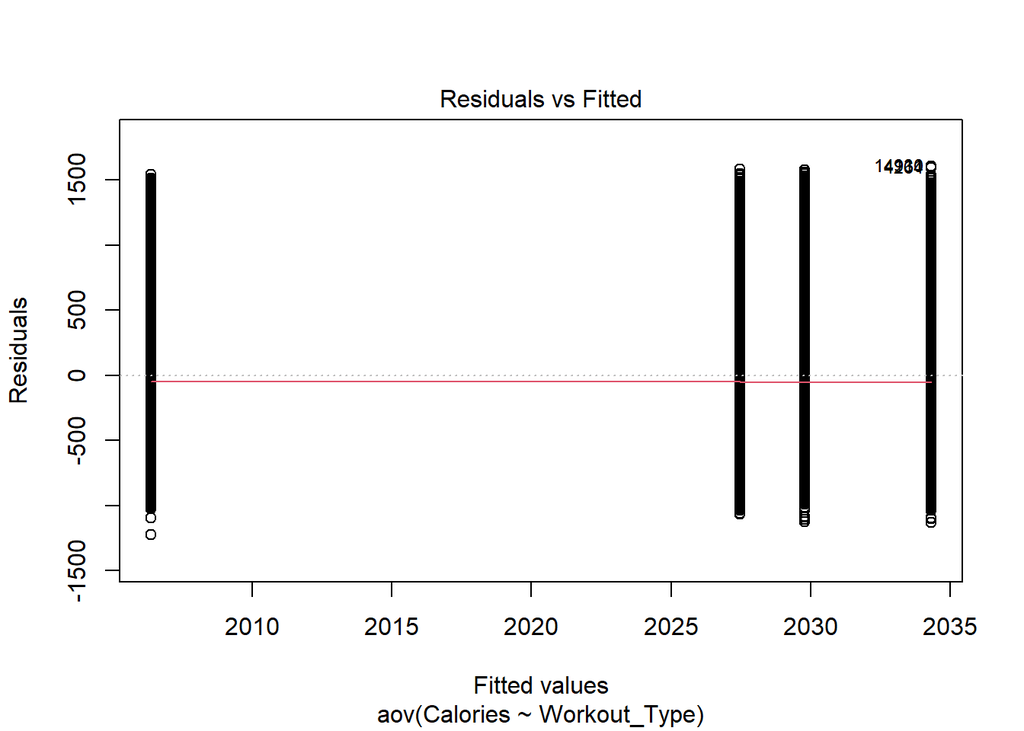

```r
plot(modelo_anova, which = 1)
```

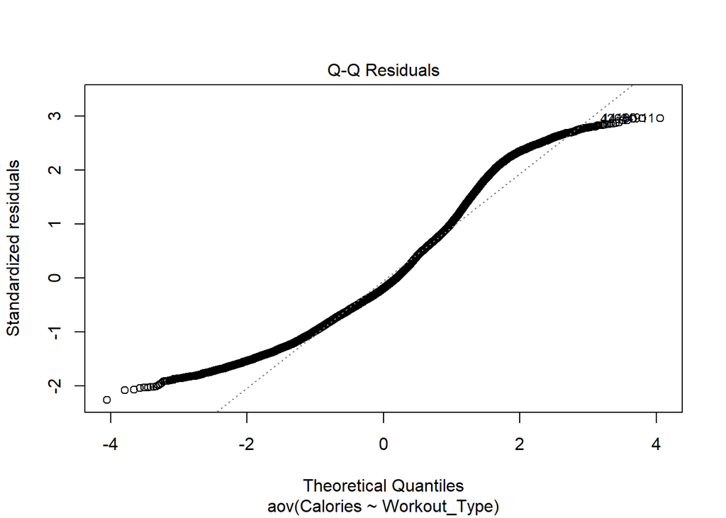

```r
plot(modelo_anova, which = 2)
```

Procedemos a la verificacion de los supuestos de normalidad y homoscedasticidad:

```r
# Realizar la prueba T2 de Tamhane
# 1. Filtrar NAs y asegurar que es un factor (Teniamos un error al existir NA)
data_clean <- dataSet %>%
  filter(!is.na(Calories), !is.na(Workout_Type)) %>%
  mutate(Workout_Type = as.factor(as.character(Workout_Type)))

# 2. Ejecutar la prueba T2 de Tamhane con los datos limpios
test_tamhane <- tamhaneT2Test(data_clean$Calories, data_clean$Workout_Type)

# 3. Ver resultados
print(test_tamhane)
```

```
##
##  Pairwise comparisons using Tamhane's T2-test for unequal variances
```

```
## data: data_clean$Calories and data_clean$Workout_Type
```

```
##          Cardio HIIT  Strength
## HIIT     1.000  -     -
## Strength 0.263  0.168 -
## Yoga     0.989  0.999 0.054
```

```
##
## P value adjustment method: T2 (Sidak)
```

```
## alternative hypothesis: two.sided
```

Al observar los p-valores ajustados por el método T2 , vemos que ninguna de las comparaciones entre pares es estadísticamente significativa (todos los valores son mayores a 0.05):

- **HIIT vs Cardio** ($p = 1.000$): No hay diferencia alguna entre estos dos grupos.Strength vs Cardio ($p = 0.263$): No hay diferencia significativa.
- **Yoga vs Cardio** ($p = 0.989$): No hay diferencia significativa.Strength vs HIIT ($p = 0.168$): No hay diferencia significativa.
- **Yoga vs Strength** ($p = 0.054$): Esta es la comparación más cercana a la significancia, pero al estar por encima de 0.05, técnicamente se considera que no hay diferencia significativa entre el Yoga y el entrenamiento de Fuerza.

### 4.6.1. Normalidad de los residuos

```r
# Extraer los residuos del modelo ANOVA
residuos_anova <- residuals(modelo_anova)

# Ejecutar el test de Anderson-Darling
ad.test(residuos_anova)
```

```
##
##  Anderson-Darling normality test
##
## data:  residuos_anova
## A = 223.63, p-value < 2.2e-16
```

Como podemos apreciar el p-value que nos devuelve nos indica que debemos rechazar la $H_0$: Los datos siguen una distribución normal).

Aunque tengamos este resultado con el p-value podemos seguir usando este análisis para la toma de decisiones, puesto que:

- **Tamaño de muestra** ($n$): El dataset cuenta con aproximadamente 20,000 observaciones, lo cual supera con creces el umbral de $n \geq 30$.
- **Teorema del Límite Central** (TLC): Gracias al TLC, la distribución de la media muestral tiende a la normalidad independientemente de la distribución de los datos originales.
- **Robustez del ANOVA**: Con una muestra tan grande, las desviaciones en la normalidad de los residuos tienen un impacto mínimo en la tasa de error tipo I (falsos positivos) del test F.

### 4.6.2. Homocedasticidad de los residuos

```r
# ANOVA de Welch
oneway.test(Calories ~ Workout_Type, data = dataSet, var.equal = FALSE)
```

```
##
##  One-way analysis of means (not assuming equal variances)
##
## data:  Calories and Workout_Type
## F = 2.6961, num df = 3, denom df = 11105, p-value = 0.04427
```

Tras lo visto en el ANOVA de Welch podemos decir que teniendo como resultado $F = 2.6961$, $p-value = 0.04427$, esto implica que el p-valor es menor a 0.05 lo que indica que existen diferencias estadísticamente significativas en las calorías medias quemadas según el tipo de entrenamiento.

```r
# Realizamos el test de Levene

leveneTest(Calories ~ Workout_Type, data = dataSet)
```

```
## Levene's Test for Homogeneity of Variance (center = median)
##          Df F value Pr(>F)
## group     3  1.3087 0.2696
##       19996
```

Centrandonos en el test de Levene podemos extraer lo siguiente teniendo como resultado $Pr(>F) = 0.2696$:

- Dado que el p-valor ($0.2696$) es mayor a 0.05, no podemos rechazar la hipótesis nula de igualdad de varianzas.
- A diferencia de lo que sugería la inspección visual inicial, estadísticamente existe homocedasticidad, aunque visualmente las columnas en los valores ajustados más altos parecen tener una densidad de puntos ligeramente distinta, el Test de Levene confirma que la amplitud de la dispersión es comparable en todos los grupos.

## 5. ANOVA multifactorial

### 5.1. Crea la variable BIM para mayores de 25 igual a “Alto”

```r
dataSet$BMI <- dataSet$Weight_kg / (dataSet$Height_m^2)

# 1. Alto (> 25) y 0 para Normal/Bajo (<= 25)
dataSet$BMI_bin <- ifelse(dataSet$BMI > 25, "Alto", "Normal/Bajo")

# 2. Convertimos a factor para análisis posteriores
dataSet$BMI_bin <- as.factor(dataSet$BMI_bin)

table(dataSet$BMI_bin)
```

```
##
##        Alto Normal/Bajo
##        8892       11108
```

### 5.2. Análisis visual de los efectos principales y posibles interacciones

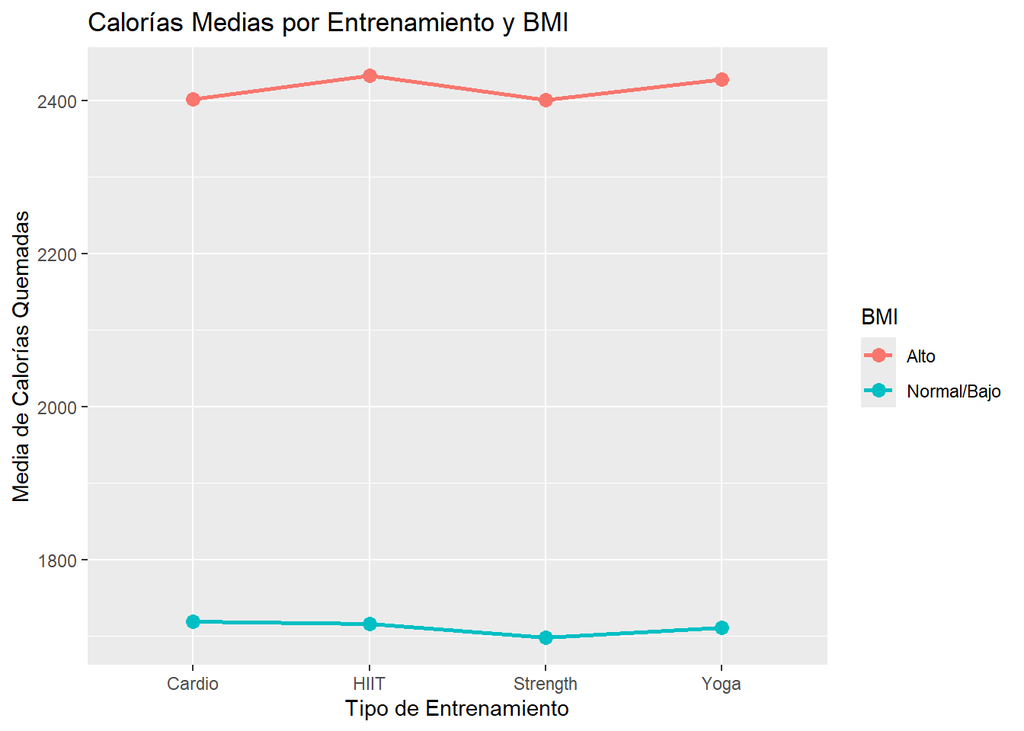

```r
# Calculamos medias para el gráfico
datos_resumen <- dataSet %>%
  group_by(Workout_Type, BMI_bin) %>%
  summarise(Mean_Calories = mean(Calories, na.rm = TRUE), .groups = 'drop')

# Generamos el gráfico de interacción
ggplot(datos_resumen, aes(x = Workout_Type, y = Mean_Calories, color = BMI_bin, group = BMI_bin)) +
  geom_line(size = 1) +
  geom_point(size = 3) +
  labs(title = "Calorías Medias por Entrenamiento y BMI",
       x = "Tipo de Entrenamiento",
       y = "Media de Calorías Quemadas",
       color = "BMI")
```

### 5.3. Hipótesis nula y alternativa

1. **Hipótesis para el Factor Workout_Type:**
- $H_0$: El promedio de calorías quemadas es igual para todos los tipos de entrenamiento.
- $H_1$: El promedio de calorías quemadas varía en, al menos, un tipo de entrenamiento.
2. **Hipótesis para el Factor BMI_bin**:
- $H_0$: El promedio de calorías quemadas es igual para personas con BMI Alto y BMI Normal/Bajo.
- $H_1$: Existe una diferencia significativa en el promedio de calorías quemadas según el grupo de BMI.
3. **Hipótesis para la Interacción: Workout_Type - BMI_bin**:
- $H_0$: No existe interacción entre el tipo de entrenamiento y el BMI (el efecto del entrenamiento es el mismo para ambos grupos de BMI).
- $H_1$: Existe interacción (el efecto del tipo de entrenamiento sobre las calorías depende de si la persona tiene un BMI alto o no).

### 5.4. Cálculo del modelo

```r
# ANOVA de dos vías con interacción
modelo_factorial <- aov(Calories ~ Workout_Type * BMI_bin, data = dataSet)

# Resumen de los resultados
summary(modelo_factorial)
```

```
##                         Df    Sum Sq   Mean Sq   F value  Pr(>F)
## Workout_Type             3 2.337e+06 7.789e+05     4.558 0.00339 **
## BMI_bin                  1 2.453e+09 2.453e+09 14354.053 < 2e-16 ***
## Workout_Type:BMI_bin     3 9.109e+05 3.036e+05     1.777 0.14918
## Residuals            19992 3.416e+09 1.709e+05
## ---
## Signif. codes:  0 '***' 0.001 '**' 0.01 '*' 0.05 '.' 0.1 ' ' 1
```

El análisis de varianza de dos vías muestra que tanto el tipo de entrenamiento ($p = 0.00339$) como la categoría de BMI ($p < 0.001$) influyen de manera significativa y aislada en el gasto calórico. Siendo el índice de masa corporal es el factor determinante predominante. Por otro lado, no se encontró una interacción significativa entre ambos factores ($p = 0.149$), lo que indica que el beneficio calórico de cada tipo de ejercicio es consistente independientemente de si el practicante tiene un BMI alto o normal.

### 5.5. Adecuación del modelo

Comenzaremos por la comprobación visual:

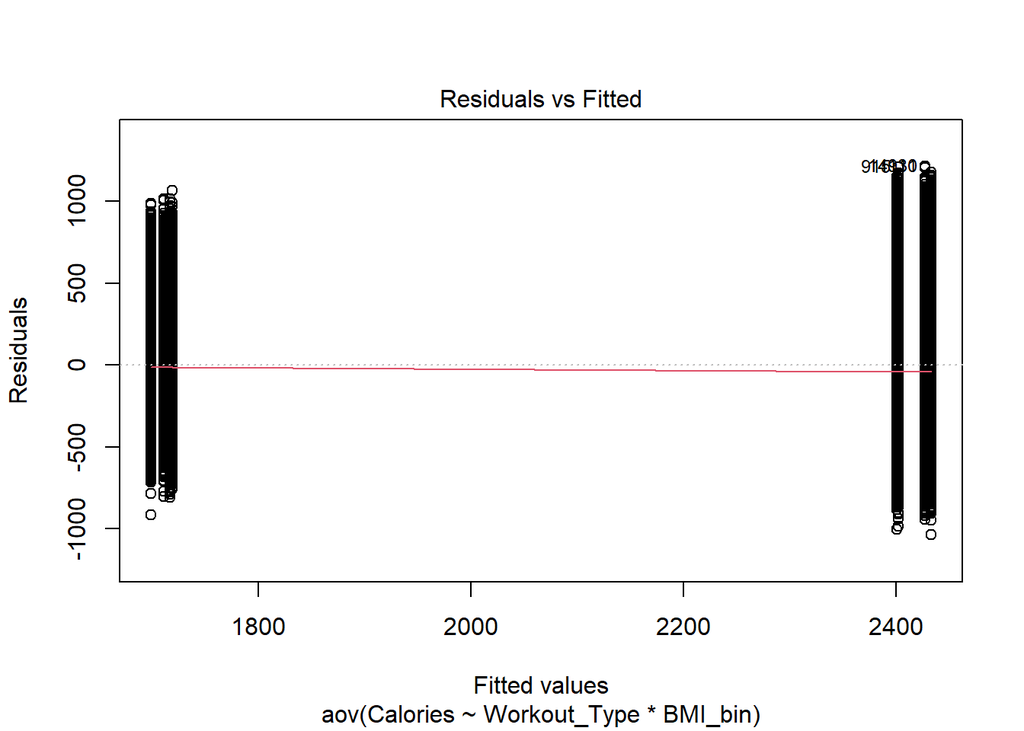

```r
plot(modelo_factorial, which = 1)
```

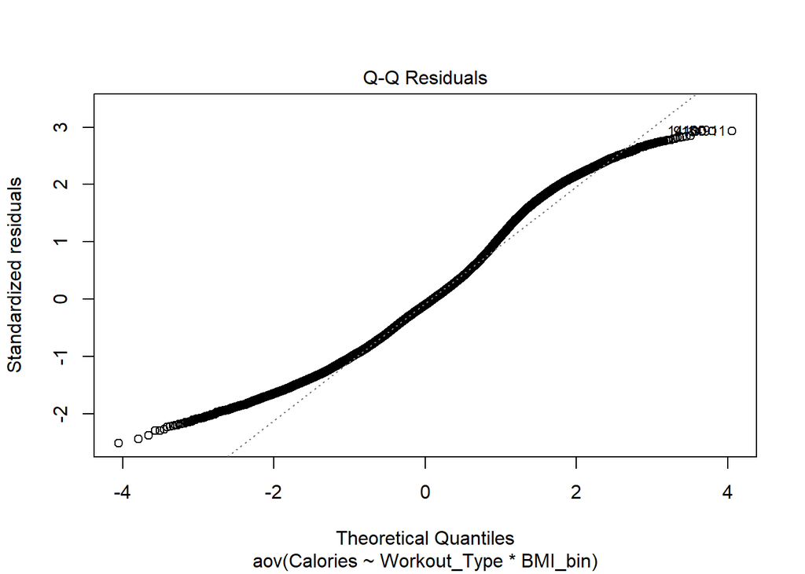

```r
plot(modelo_factorial, which = 2)
```

```r
leveneTest(Calories ~ Workout_Type * BMI_bin, data = dataSet)
```

```
## Levene's Test for Homogeneity of Variance (center = median)
##          Df F value    Pr(>F)
## group     7  219.34 < 2.2e-16 ***
##       19992
## ---
## Signif. codes:  0 '***' 0.001 '**' 0.01 '*' 0.05 '.' 0.1 ' ' 1
```

### 5.6. Interpretación de los resultados

Pasamos ahora a comprobar la **homocedasticidad** mediante el test de Levene:

Al obtener $Pr(>F) < 2.2e-16$ se rechaza de forma contundente la hipótesis nula de homocedasticidad, en consecuencia podemos afirmar que existe una heterocedasticidad severa cuando consideramos las 8 posibles combinaciones (4 tipos de entrenamiento × 2 niveles de BMI). La variabilidad de las calorías quemadas no es constante, lo que invalida uno de los supuestos fundamentales del ANOVA de dos vías convencional.  
Esto genera una contradicción con respecto al gráfico visual del ANOVA de una vía veíamos una dispersión que parecía manejable, el test formal para el modelo factorial detecta que al combinar ambos factores, las diferencias de varianza entre grupos explotan.  
Esto se debe al existir en el test un grupo específico (por ejemplo, HIIT con BMI Alto) que tiene una dispersión de datos muchísimo mayor que otros (como Yoga con BMI Bajo).